# Token Frequency Rescorla

Zachary Houghton

2023-11-29

# Rescorla Predictions

Libraries:

```r
library(tidyverse)
library(ndl)
library(arm)
#logistic perceptron from neural net
source("RescorlaLogistic.R")
```

Let’s test what the RW predictions for our experiment are.

## Conditions Tables

Table1:

| **Condition1** | #of tokens | #of types | **Condition2** | #of tokens | #of types | **Condition3** | #of tokens | #of types |
| --- | --- | --- | --- | --- | --- | --- | --- | --- |
| *dan* | 12 | 12 | *dan* | 12 | 3 | *dan* | 12 | 12 |
| *nem* | 12 | 3 | *nem* | 3 | 3 | *nem* | 3 | 3 |
| *sil* | 6 | 6 | *sil* | 6 | 6 | *sil* | 6 | 6 |
| *shoon* | 6 | 6 | *shoon* | 6 | 6 | *shoon* | 6 | 6 |
| **Condition4** |  |  | **Condition5** |  |  | **Condition6** | #of tokens | #of types |
| *dan* | 12 | 3 | *dan* | 3 | 3 | *dan* | 3 | 3 |
| *nem* | 12 | 12 | *nem* | 12 | 3 | *nem* | 12 | 12 |
| *sil* | 6 | 6 | *sil* | 6 | 6 | *sil* | 6 | 6 |
| *shoon* | 6 | 6 | *shoon* | 6 | 6 | *shoon* | 6 | 6 |

Table2

| **Condition** | **dan token** | **nem token** | **sil token** | **shoon token** | **dan type** | **nem type** | **sil type** | **shoon type** |
| --- | --- | --- | --- | --- | --- | --- | --- | --- |
| 1 | 12 | 12 | 6 | 6 | 12 | 3 | 6 | 6 |
| 2 | 12 | 3 | 6 | 6 | 3 | 3 | 6 | 6 |
| 3 | 12 | 3 | 6 | 6 | 12 | 3 | 6 | 6 |
| 4 | 12 | 12 | 6 | 6 | 3 | 12 | 6 | 6 |
| 5 | 3 | 12 | 6 | 6 | 3 | 3 | 6 | 6 |
| 6 | 3 | 12 | 6 | 6 | 3 | 12 | 6 | 6 |

## Condition 1 (dan type): 12 token, 12 type (nem 12 tokens 3 types)

### Preparing Data

```r
#cues = c('bal', 'berko', 'kora', 'nako', 'pipa', 'bani', 'chool', 'kudom', 'osto', 'vorke', 'bin', 'mero', 'pil', 'shinti', 'shinder', 'bassi', 'lucko', 'runde')
#outcomes = c('dan', 'nem', 'sil', 'shoon')

#data_cond1 = expand.grid(cues, outcomes) %>%
  #mutate(frequency = ifelse(Var2 == 'dan', 1, ifelse(Var1 %in% c('bal', 'berko', 'kora') & Var2 == 'nem', 4, ifelse(Var1 %in% c('bal', 'berko', 'kora') & Var2 %in% c('sil', 'shoon'), 2, 0)))) %>%
  #mutate_if(is.factor, as.character) #factors break the RW model code

#data_cond1$frequency = data_cond1$frequency * 5 #in our experiment each block repeats 5 times

#colnames(data_cond1) = c('Cues', 'Outcomes', 'Frequency')

#data_cond1 = data_cond1 %>%
  #mutate(Cues = paste(Cues, Outcomes, sep = '_'))

#data_cond1_v2 = read_csv('data_cond1_v2.csv') #%>%
  #mutate()


#data_cond1 = data_cond1_v2 #%>%
  #full_join(data_cond1_v2)

#data_cond1$cues = expand.grid(orthoCoding(cues), outcomes)

#data_test = data.frame(rep(c(paste(orthoCoding(cues),"dim_sg",sep="_"),paste(orthoCoding(cues),("big_pl"),sep="_")),2)) %>%
  #mutate(Outcomes = rep(c('nem', 'dan', 'shoon', 'sil'), each = length(cues)))

#colnames(data_test) = c('cue', 'outcome')

cond1 = read_csv('../Experiment/Condition1.csv')
cond1 = cond1 %>%
  mutate(stem = orthoCoding(stem)) %>%
  mutate(type = ifelse((suffix == 'dan' | suffix == 'sil'), 'big_pl', 'dim_sg'))

cond1 = cond1 %>%
  mutate(key = paste0(stem, '_', type))

cond1_key = cond1 %>%
  group_by(key, suffix) %>%
  summarize(frequency = table(key))
```

[output not shown]

```r
colnames(cond1_key) = c('Cues', 'Outcomes', 'Frequency')

data_cond1 = cond1_key %>%
  mutate(Frequency = as.numeric(Frequency) * 5)
```

### Rescorla Predictions

We’ll use the RW-model with logistic function.

As a reminder, the question we’re investigating is whether type or token frequency (or some combination of both) affects the generalizability of a morpheme (this is operationalized as whether type or token frequency affects the *associability,* or the weight, of one cue with the plural outcome outcome).

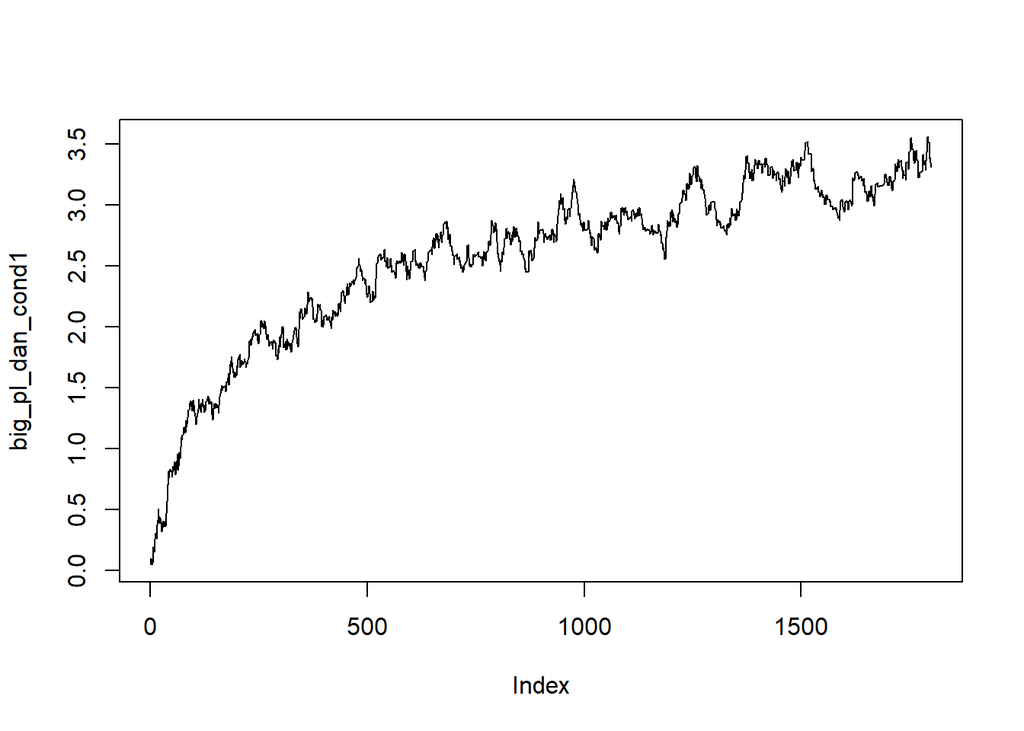

```r
n = 10
b = sqrt(.1)

big_dan_cond1 = RescorlaLogistic(data_cond1, nruns = n, traceCue='big', traceOutcome = 'dan', beta2=b, alpha=b, beta1=b, ap = F) #ap = T means you're learning something if the cue is absent
pl_dan_cond1 = RescorlaLogistic(data_cond1, nruns = n, traceCue='pl', traceOutcome = 'dan', beta2=b, alpha=b, beta1=b, ap = F)

dim_dan_cond1 = RescorlaLogistic(data_cond1, nruns = n, traceCue='dim', traceOutcome = 'dan', beta2=b, alpha=b, beta1=b, ap = F)
#pl_dan_cond1 = RescorlaLogistic(data_cond1, nruns = n, traceCue='pl', traceOutcome = 'dan', beta2=b, alpha=b, beta1=b, ap = F)

big_nem_cond1 = RescorlaLogistic(data_cond1, nruns = n, traceCue='big', traceOutcome = 'nem', beta2=b, alpha=b, beta1=b, ap = F)
pl_nem_cond1 = RescorlaLogistic(data_cond1, nruns = n, traceCue='pl', traceOutcome = 'nem', beta2=b, alpha=b, beta1=b, ap = F)

dim_nem_cond1 = RescorlaLogistic(data_cond1, nruns = n, traceCue='dim', traceOutcome = 'nem', beta2=b, alpha=b, beta1=b, ap = F)
#pl_nem_cond1 = RescorlaLogistic(data_cond1, nruns = n, traceCue='pl', traceOutcome = 'nem', beta2=b, alpha=b, beta1=b, ap = F)

big_pl_dan_cond1 = big_dan_cond1$weightvector + pl_dan_cond1$weightvector
dim_pl_dan_cond1 = dim_dan_cond1$weightvector + pl_dan_cond1$weightvector
big_pl_nem_cond1 = big_nem_cond1$weightvector + pl_nem_cond1$weightvector
dim_pl_nem_cond1 = dim_nem_cond1$weightvector + pl_nem_cond1$weightvector


plot(big_pl_dan_cond1, type='l' )
```

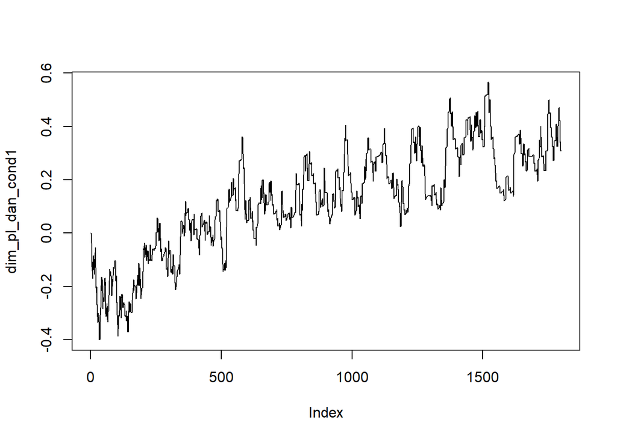

```r
plot(dim_pl_dan_cond1, type = 'l')
```

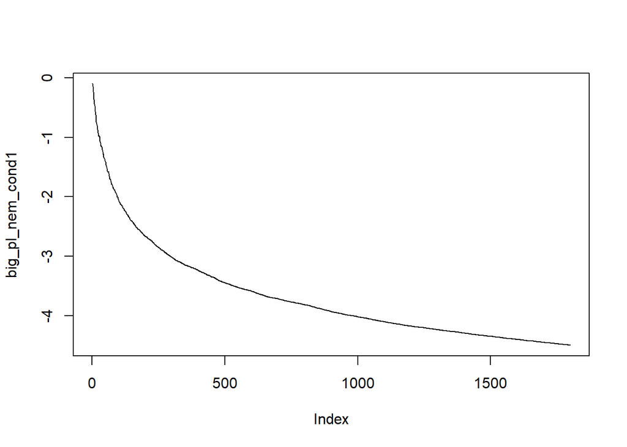

```r
plot(big_pl_nem_cond1, type = 'l')
```

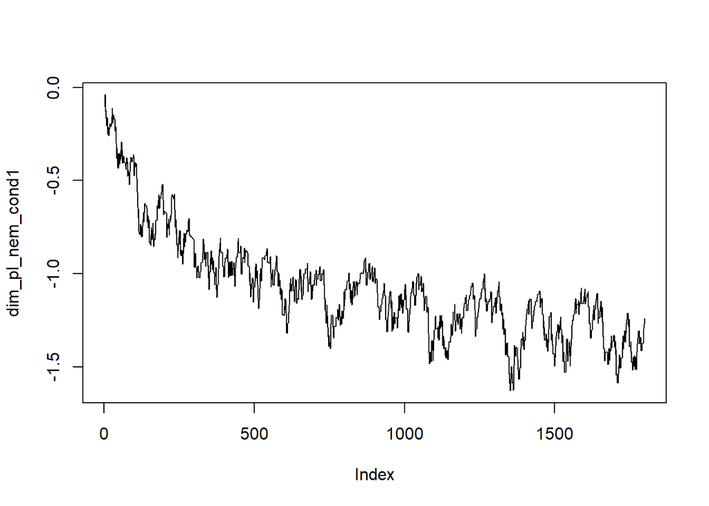

```r
plot(dim_pl_nem_cond1, type = 'l')
```

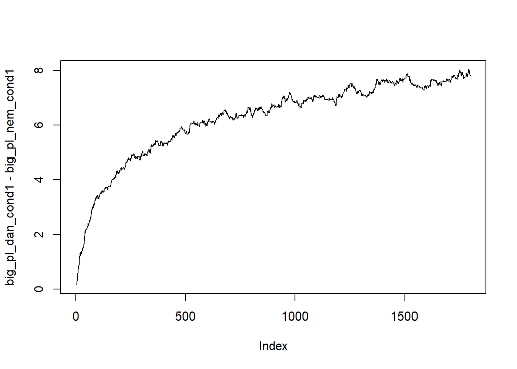

```r
plot(big_pl_dan_cond1 - big_pl_nem_cond1, type = 'l')
```

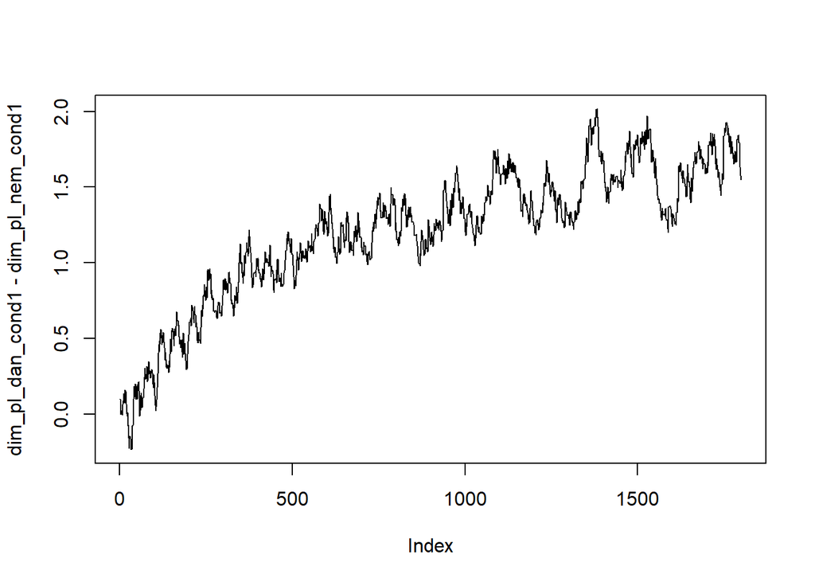

```r
plot(dim_pl_dan_cond1 - dim_pl_nem_cond1, type = 'l')
```

## Condition 2 (dan token): 12 tokens, 3 types

```r
cond2 = read_csv('../Experiment/Condition2.csv')
cond2 = cond2 %>%
  mutate(stem = orthoCoding(stem)) %>%
  mutate(type = ifelse((suffix == 'dan' | suffix == 'sil'), 'big_pl', 'dim_sg'))

cond2 = cond2 %>%
  mutate(key = paste0(stem, '_', type))

cond2_key = cond2 %>%
  group_by(key, suffix) %>%
  summarize(frequency = table(key))
```

[output not shown]

```r
colnames(cond2_key) = c('Cues', 'Outcomes', 'Frequency')

data_cond2 = cond2_key %>%
  mutate(Frequency = as.numeric(Frequency) * 5)
```

### Rescorla Predictions

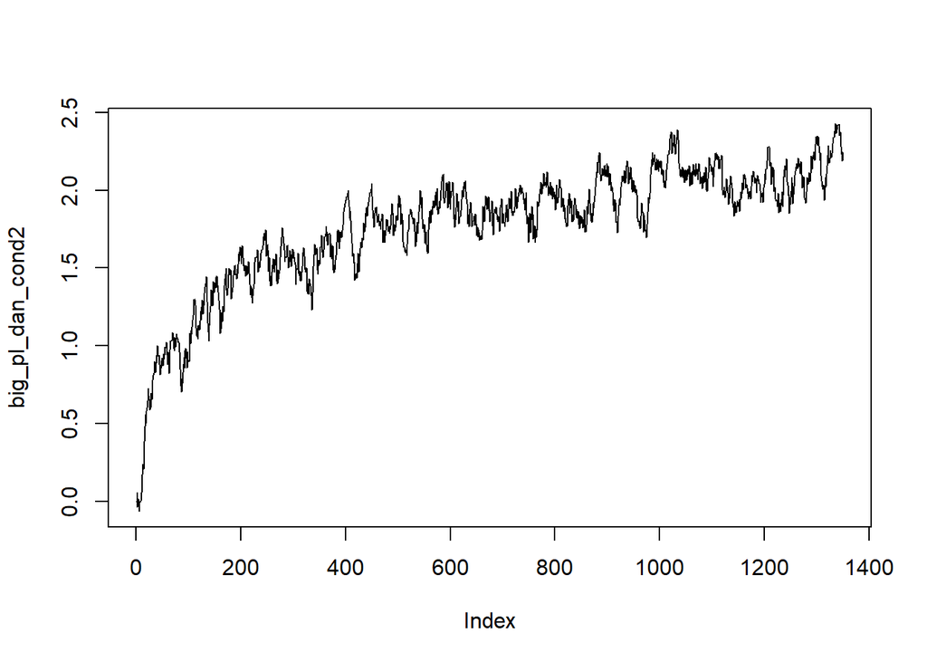

```r
n = 10
b = sqrt(.1)

big_dan_cond2 = RescorlaLogistic(data_cond2, nruns = n, traceCue='big', traceOutcome = 'dan', beta2=b, alpha=b, beta1=b, ap = F) #ap = T means you're learning something if the cue is absent
pl_dan_cond2 = RescorlaLogistic(data_cond2, nruns = n, traceCue='pl', traceOutcome = 'dan', beta2=b, alpha=b, beta1=b, ap = F)

dim_dan_cond2 = RescorlaLogistic(data_cond2, nruns = n, traceCue='dim', traceOutcome = 'dan', beta2=b, alpha=b, beta1=b, ap = F)
#pl_dan_cond1 = RescorlaLogistic(data_cond1, nruns = n, traceCue='pl', traceOutcome = 'dan', beta2=b, alpha=b, beta1=b, ap = F)

big_nem_cond2 = RescorlaLogistic(data_cond2, nruns = n, traceCue='big', traceOutcome = 'nem', beta2=b, alpha=b, beta1=b, ap = F)
pl_nem_cond2 = RescorlaLogistic(data_cond2, nruns = n, traceCue='pl', traceOutcome = 'nem', beta2=b, alpha=b, beta1=b, ap = F)

dim_nem_cond2 = RescorlaLogistic(data_cond2, nruns = n, traceCue='dim', traceOutcome = 'nem', beta2=b, alpha=b, beta1=b, ap = F)
#pl_nem_cond1 = RescorlaLogistic(data_cond1, nruns = n, traceCue='pl', traceOutcome = 'nem', beta2=b, alpha=b, beta1=b, ap = F)

big_pl_dan_cond2 = big_dan_cond2$weightvector + pl_dan_cond2$weightvector
dim_pl_dan_cond2 = dim_dan_cond2$weightvector + pl_dan_cond2$weightvector
big_pl_nem_cond2 = big_nem_cond2$weightvector + pl_nem_cond2$weightvector
dim_pl_nem_cond2 = dim_nem_cond2$weightvector + pl_nem_cond2$weightvector


plot(big_pl_dan_cond2, type='l' )
```

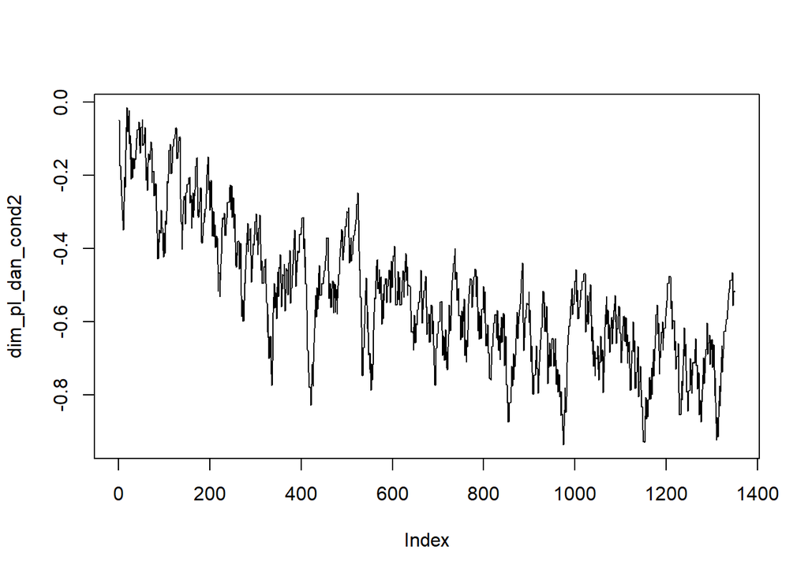

```r
plot(dim_pl_dan_cond2, type = 'l')
```

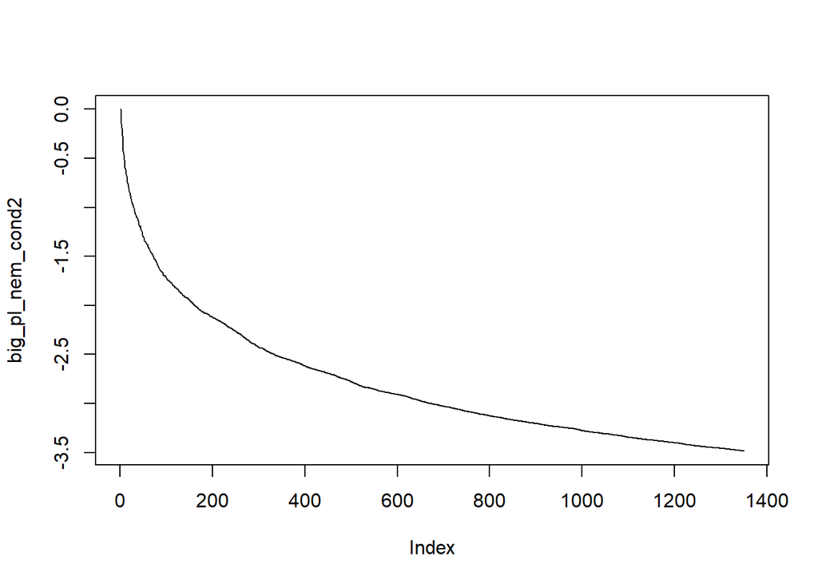

```r
plot(big_pl_nem_cond2, type = 'l')
```

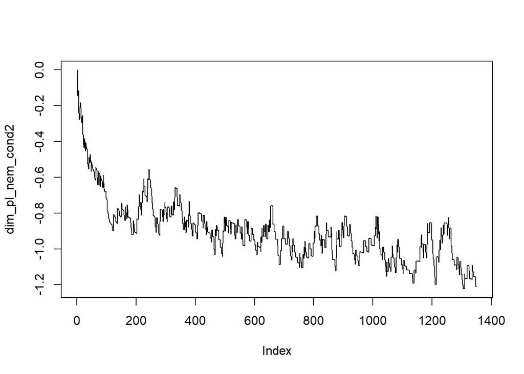

```r
plot(dim_pl_nem_cond2, type = 'l')
```

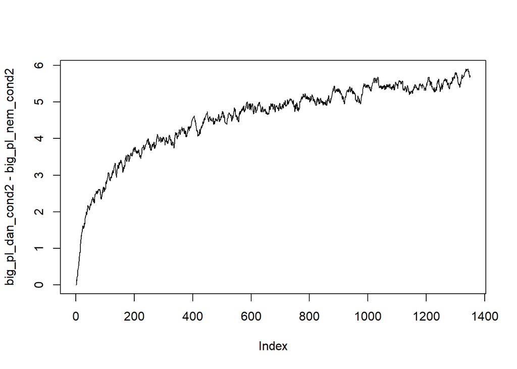

```r
plot(big_pl_dan_cond2 - big_pl_nem_cond2, type = 'l')
```

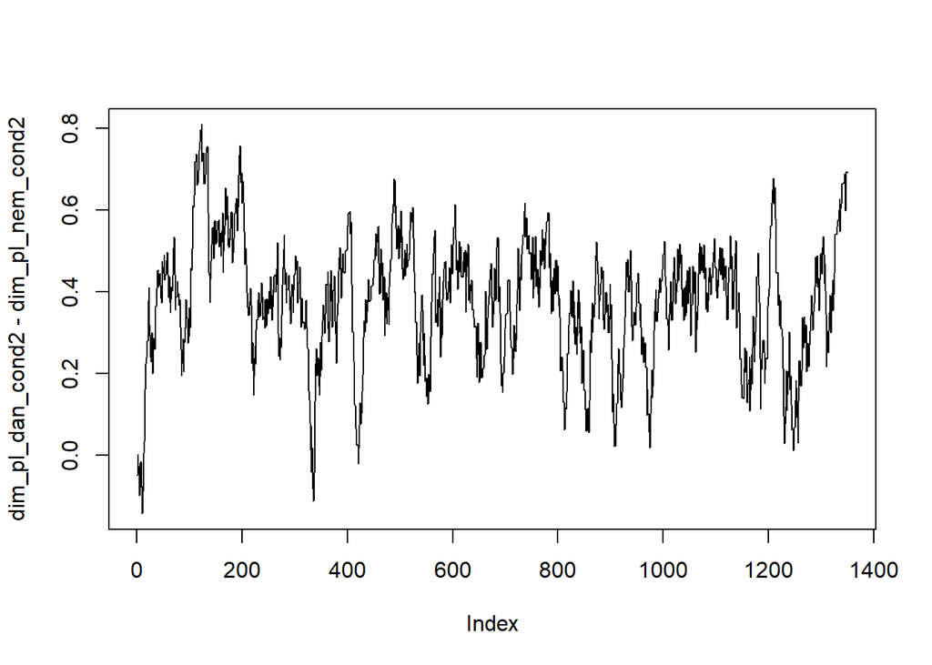

```r
plot(dim_pl_dan_cond2 - dim_pl_nem_cond2, type = 'l')
```

## Condition 3 (dan type and token): 12 tokens, 12 types (nem 3 tokens, 3 types)

```r
cond3 = read_csv('../Experiment/Condition3.csv')
cond3 = cond3 %>%
  mutate(stem = orthoCoding(stem)) %>%
  mutate(type = ifelse((suffix == 'dan' | suffix == 'sil'), 'big_pl', 'dim_sg'))

cond3 = cond3 %>%
  mutate(key = paste0(stem, '_', type))

cond3_key = cond3 %>%
  group_by(key, suffix) %>%
  summarize(frequency = table(key))
```

[output not shown]

```r
colnames(cond3_key) = c('Cues', 'Outcomes', 'Frequency')

data_cond3 = cond3_key %>%
  mutate(Frequency = as.numeric(Frequency) * 5)
```

### Rescorla Predictions

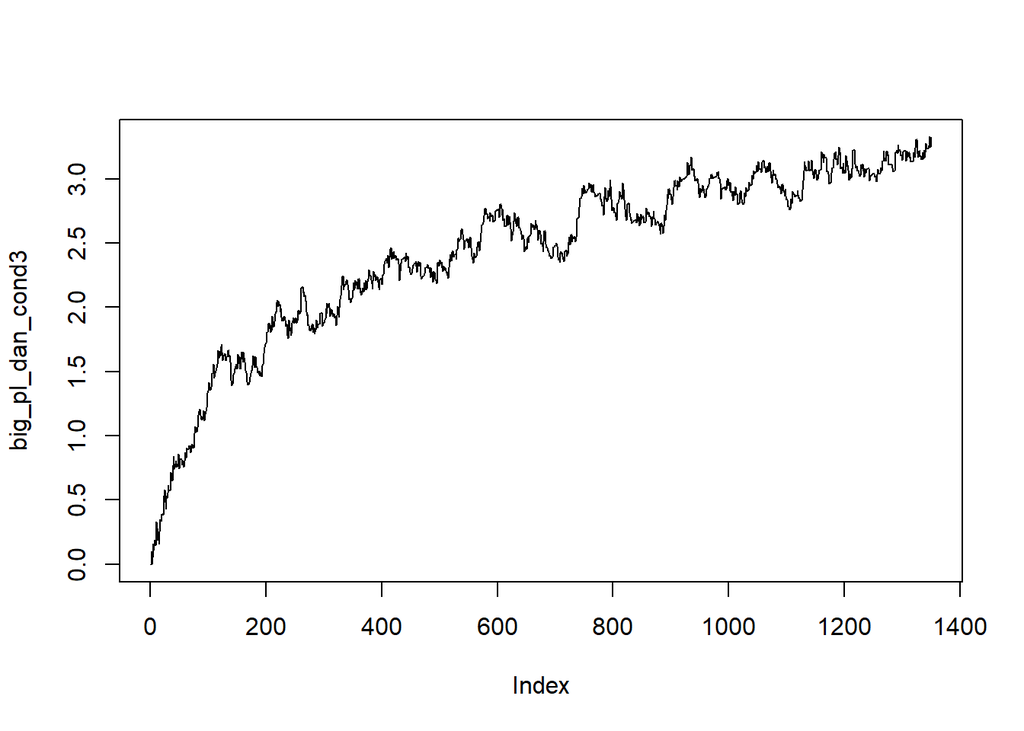

```r
n = 10
b = sqrt(.1)

big_dan_cond3 = RescorlaLogistic(data_cond3, nruns = n, traceCue='big', traceOutcome = 'dan', beta2=b, alpha=b, beta1=b, ap = F) #ap = T means you're learning something if the cue is absent
pl_dan_cond3 = RescorlaLogistic(data_cond3, nruns = n, traceCue='pl', traceOutcome = 'dan', beta2=b, alpha=b, beta1=b, ap = F)

dim_dan_cond3 = RescorlaLogistic(data_cond3, nruns = n, traceCue='dim', traceOutcome = 'dan', beta2=b, alpha=b, beta1=b, ap = F)
#pl_dan_cond1 = RescorlaLogistic(data_cond1, nruns = n, traceCue='pl', traceOutcome = 'dan', beta2=b, alpha=b, beta1=b, ap = F)

big_nem_cond3 = RescorlaLogistic(data_cond3, nruns = n, traceCue='big', traceOutcome = 'nem', beta2=b, alpha=b, beta1=b, ap = F)
pl_nem_cond3 = RescorlaLogistic(data_cond3, nruns = n, traceCue='pl', traceOutcome = 'nem', beta2=b, alpha=b, beta1=b, ap = F)

dim_nem_cond3 = RescorlaLogistic(data_cond3, nruns = n, traceCue='dim', traceOutcome = 'nem', beta2=b, alpha=b, beta1=b, ap = F)
#pl_nem_cond1 = RescorlaLogistic(data_cond1, nruns = n, traceCue='pl', traceOutcome = 'nem', beta2=b, alpha=b, beta1=b, ap = F)

big_pl_dan_cond3 = big_dan_cond3$weightvector + pl_dan_cond3$weightvector
dim_pl_dan_cond3 = dim_dan_cond3$weightvector + pl_dan_cond3$weightvector
big_pl_nem_cond3 = big_nem_cond3$weightvector + pl_nem_cond3$weightvector
dim_pl_nem_cond3 = dim_nem_cond3$weightvector + pl_nem_cond3$weightvector


plot(big_pl_dan_cond3, type='l' )
```

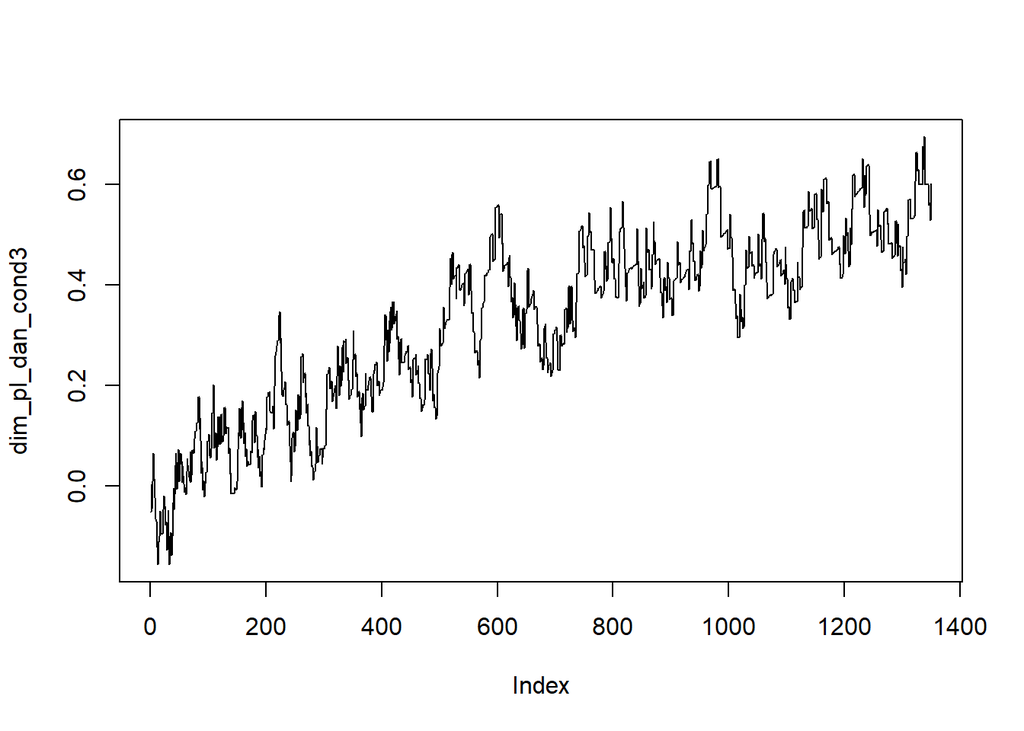

```r
plot(dim_pl_dan_cond3, type = 'l')
```

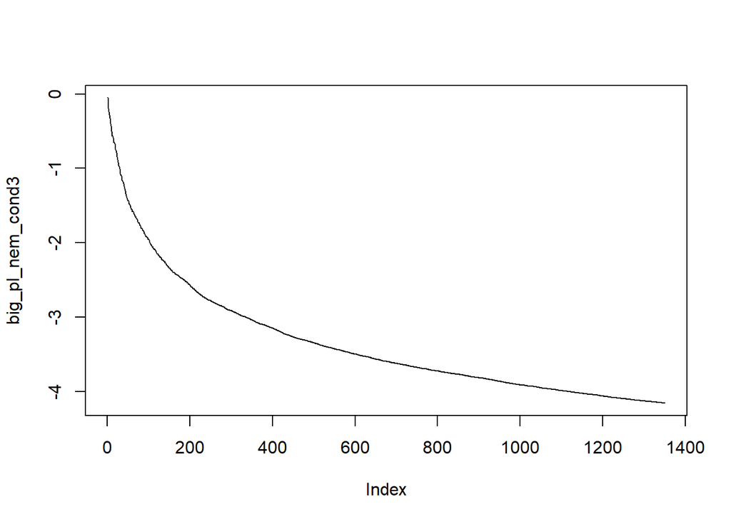

```r
plot(big_pl_nem_cond3, type = 'l')
```

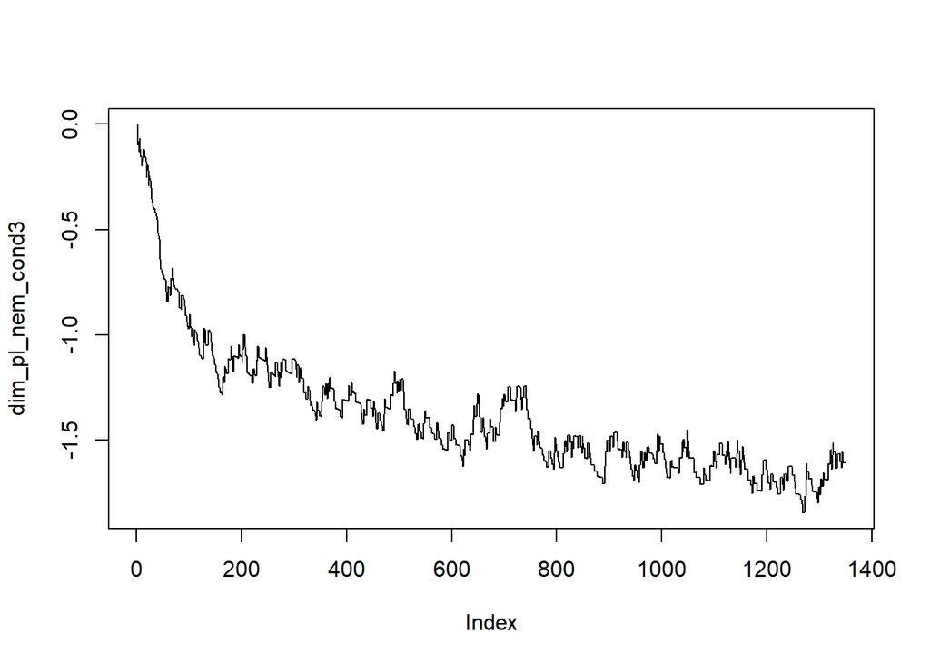

```r
plot(dim_pl_nem_cond3, type = 'l')
```

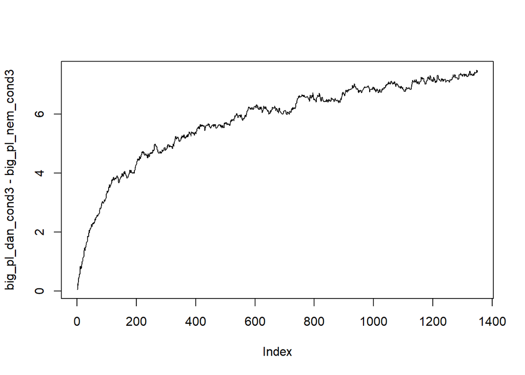

```r
plot(big_pl_dan_cond3 - big_pl_nem_cond3, type = 'l')
```

```r
plot(dim_pl_dan_cond3 - dim_pl_nem_cond3, type = 'l')
```

[output not shown]

## Condition 4 (nem type): 12 token, 12 type (dan 12 token, 3 type)

```r
cond4 = read_csv('../Experiment/Condition4.csv')
cond4 = cond4 %>%
  mutate(stem = orthoCoding(stem)) %>%
  mutate(type = ifelse((suffix == 'dan' | suffix == 'sil'), 'big_pl', 'dim_sg'))

cond4 = cond4 %>%
  mutate(key = paste0(stem, '_', type))

cond4_key = cond4 %>%
  group_by(key, suffix) %>%
  summarize(frequency = table(key))
```

[output not shown]

```r
colnames(cond4_key) = c('Cues', 'Outcomes', 'Frequency')

data_cond4 = cond4_key %>%
  mutate(Frequency = as.numeric(Frequency) * 5)
```

### Rescorla Predictions

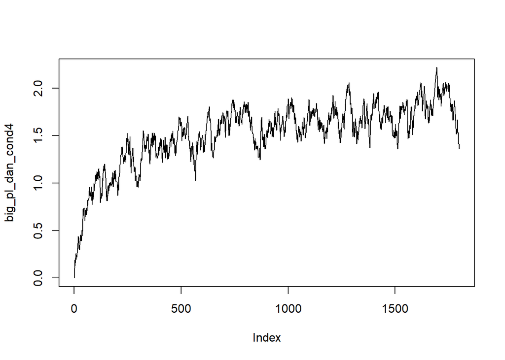

```r
n = 10
b = sqrt(.1)

big_dan_cond4 = RescorlaLogistic(data_cond4, nruns = n, traceCue='big', traceOutcome = 'dan', beta2=b, alpha=b, beta1=b, ap = F) #ap = T means you're learning something if the cue is absent
pl_dan_cond4 = RescorlaLogistic(data_cond4, nruns = n, traceCue='pl', traceOutcome = 'dan', beta2=b, alpha=b, beta1=b, ap = F)

dim_dan_cond4 = RescorlaLogistic(data_cond4, nruns = n, traceCue='dim', traceOutcome = 'dan', beta2=b, alpha=b, beta1=b, ap = F)
#pl_dan_cond1 = RescorlaLogistic(data_cond1, nruns = n, traceCue='pl', traceOutcome = 'dan', beta2=b, alpha=b, beta1=b, ap = F)

big_nem_cond4 = RescorlaLogistic(data_cond4, nruns = n, traceCue='big', traceOutcome = 'nem', beta2=b, alpha=b, beta1=b, ap = F)
pl_nem_cond4 = RescorlaLogistic(data_cond4, nruns = n, traceCue='pl', traceOutcome = 'nem', beta2=b, alpha=b, beta1=b, ap = F)

dim_nem_cond4 = RescorlaLogistic(data_cond4, nruns = n, traceCue='dim', traceOutcome = 'nem', beta2=b, alpha=b, beta1=b, ap = F)
#pl_nem_cond1 = RescorlaLogistic(data_cond1, nruns = n, traceCue='pl', traceOutcome = 'nem', beta2=b, alpha=b, beta1=b, ap = F)

big_pl_dan_cond4 = big_dan_cond4$weightvector + pl_dan_cond4$weightvector
dim_pl_dan_cond4 = dim_dan_cond4$weightvector + pl_dan_cond4$weightvector
big_pl_nem_cond4 = big_nem_cond4$weightvector + pl_nem_cond4$weightvector
dim_pl_nem_cond4 = dim_nem_cond4$weightvector + pl_nem_cond4$weightvector


plot(big_pl_dan_cond4, type='l' )
```

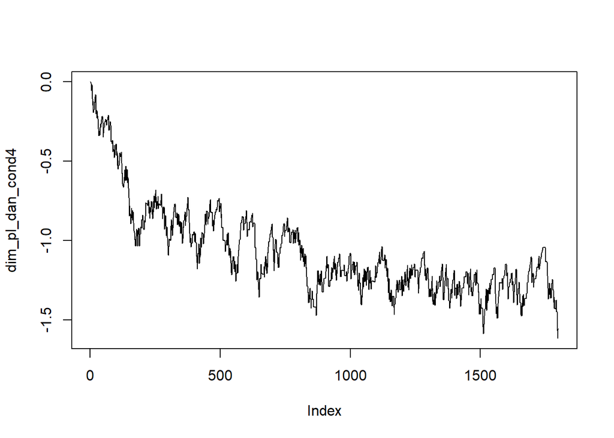

```r
plot(dim_pl_dan_cond4, type = 'l')
```

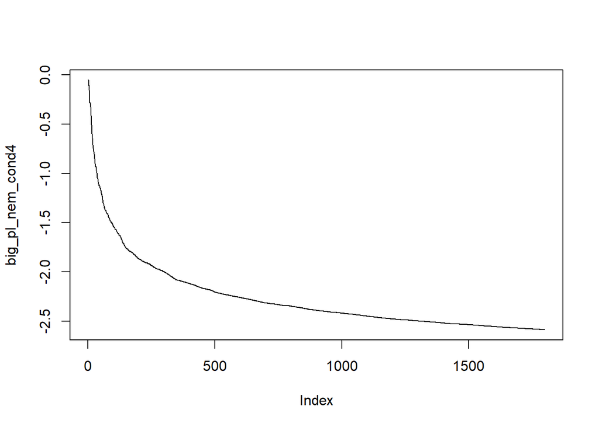

```r
plot(big_pl_nem_cond4, type = 'l')
```

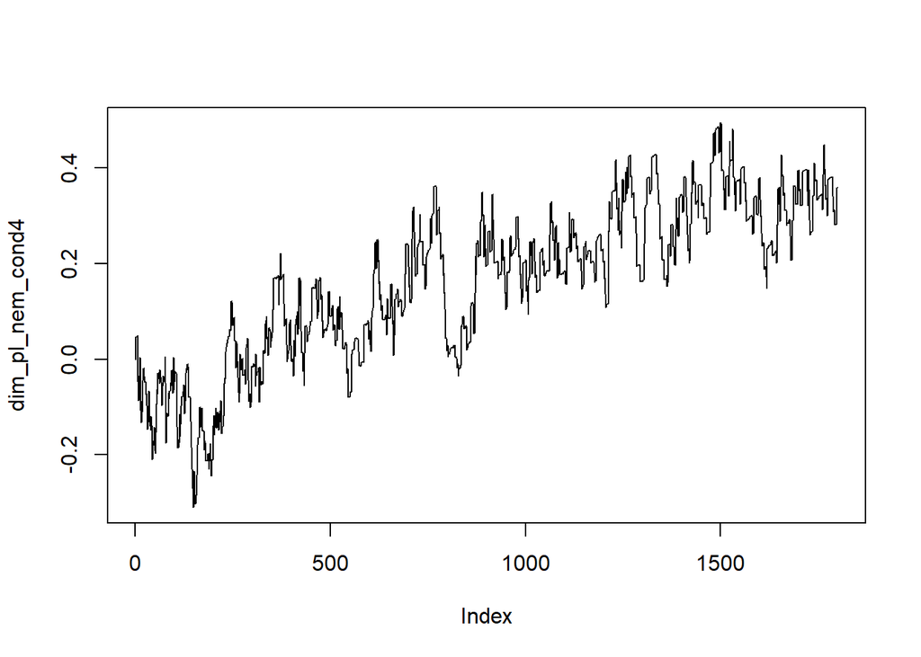

```r
plot(dim_pl_nem_cond4, type = 'l')
```

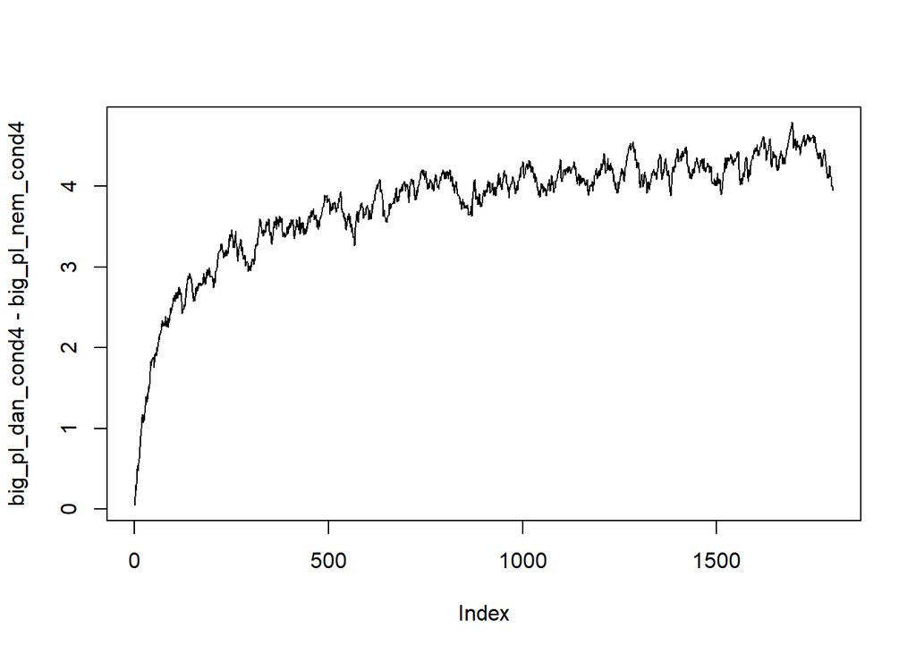

```r
plot(big_pl_dan_cond4 - big_pl_nem_cond4, type = 'l')
```

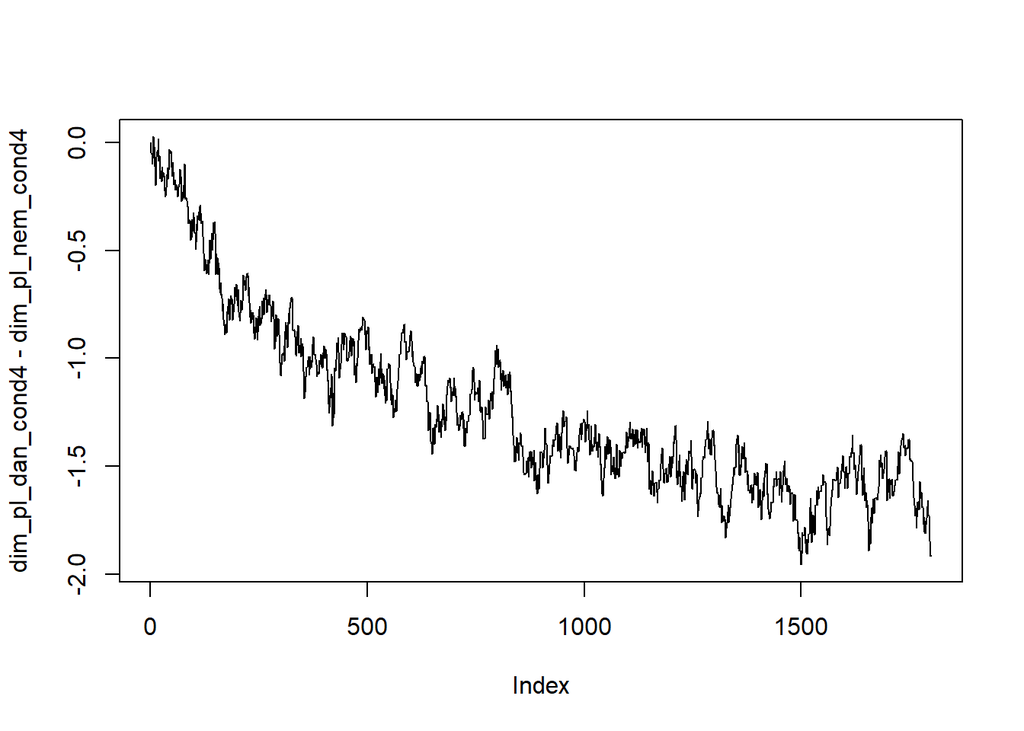

```r
plot(dim_pl_dan_cond4 - dim_pl_nem_cond4, type = 'l')
```

## Condition 5 (nem token): 12 token, 3 types (dan 3 token, 3 type)

```r
cond5 = read_csv('../Experiment/Condition5.csv')
cond5 = cond5 %>%
  mutate(stem = orthoCoding(stem)) %>%
  mutate(type = ifelse((suffix == 'dan' | suffix == 'sil'), 'big_pl', 'dim_sg'))

cond5 = cond5 %>%
  mutate(key = paste0(stem, '_', type))

cond5_key = cond5 %>%
  group_by(key, suffix) %>%
  summarize(frequency = table(key))
```

[output not shown]

```r
colnames(cond5_key) = c('Cues', 'Outcomes', 'Frequency')

data_cond5 = cond5_key %>%
  mutate(Frequency = as.numeric(Frequency) * 5)
```

### Rescorla Predictions

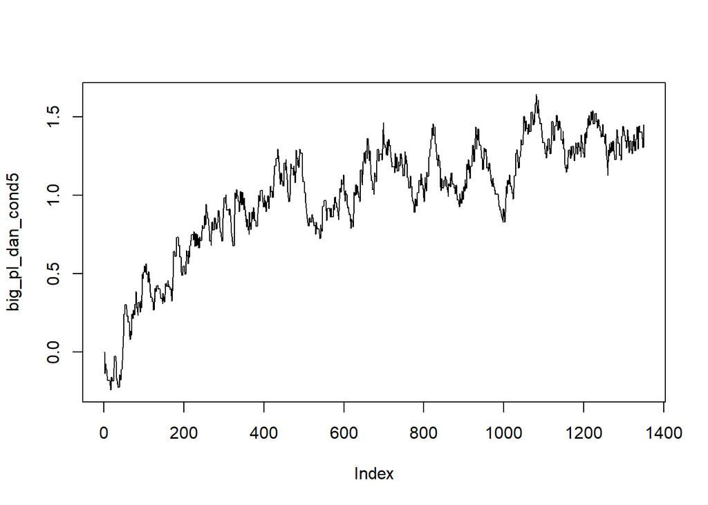

```r
n = 10
b = sqrt(.1)

big_dan_cond5 = RescorlaLogistic(data_cond5, nruns = n, traceCue='big', traceOutcome = 'dan', beta2=b, alpha=b, beta1=b, ap = F) #ap = T means you're learning something if the cue is absent
pl_dan_cond5 = RescorlaLogistic(data_cond5, nruns = n, traceCue='pl', traceOutcome = 'dan', beta2=b, alpha=b, beta1=b, ap = F)

dim_dan_cond5 = RescorlaLogistic(data_cond5, nruns = n, traceCue='dim', traceOutcome = 'dan', beta2=b, alpha=b, beta1=b, ap = F)
#pl_dan_cond1 = RescorlaLogistic(data_cond1, nruns = n, traceCue='pl', traceOutcome = 'dan', beta2=b, alpha=b, beta1=b, ap = F)

big_nem_cond5 = RescorlaLogistic(data_cond5, nruns = n, traceCue='big', traceOutcome = 'nem', beta2=b, alpha=b, beta1=b, ap = F)
pl_nem_cond5 = RescorlaLogistic(data_cond5, nruns = n, traceCue='pl', traceOutcome = 'nem', beta2=b, alpha=b, beta1=b, ap = F)

dim_nem_cond5 = RescorlaLogistic(data_cond5, nruns = n, traceCue='dim', traceOutcome = 'nem', beta2=b, alpha=b, beta1=b, ap = F)
#pl_nem_cond1 = RescorlaLogistic(data_cond1, nruns = n, traceCue='pl', traceOutcome = 'nem', beta2=b, alpha=b, beta1=b, ap = F)

big_pl_dan_cond5 = big_dan_cond5$weightvector + pl_dan_cond5$weightvector
dim_pl_dan_cond5 = dim_dan_cond5$weightvector + pl_dan_cond5$weightvector
big_pl_nem_cond5 = big_nem_cond5$weightvector + pl_nem_cond5$weightvector
dim_pl_nem_cond5 = dim_nem_cond5$weightvector + pl_nem_cond5$weightvector


plot(big_pl_dan_cond5, type='l' )
```

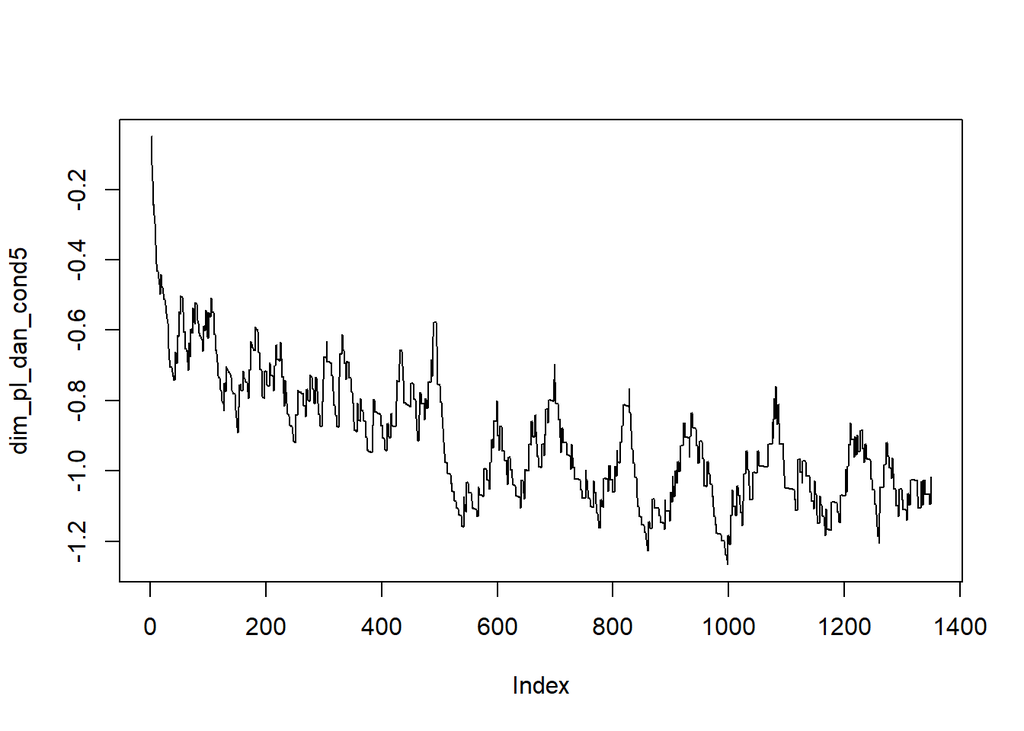

```r
plot(dim_pl_dan_cond5, type = 'l')
```

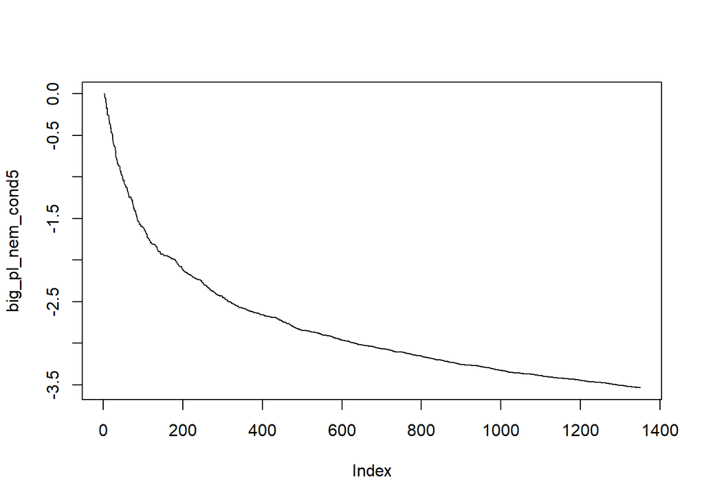

```r
plot(big_pl_nem_cond5, type = 'l')
```

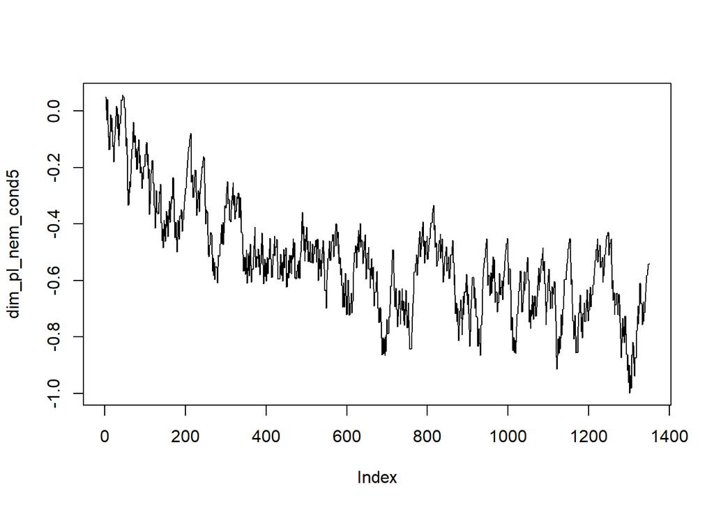

```r
plot(dim_pl_nem_cond5, type = 'l')
```

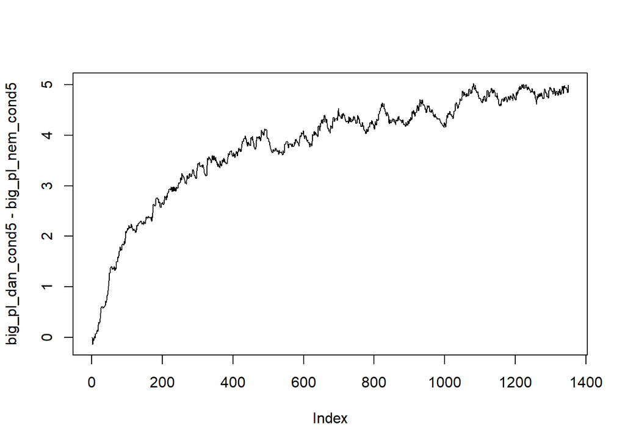

```r
plot(big_pl_dan_cond5 - big_pl_nem_cond5, type = 'l')
```

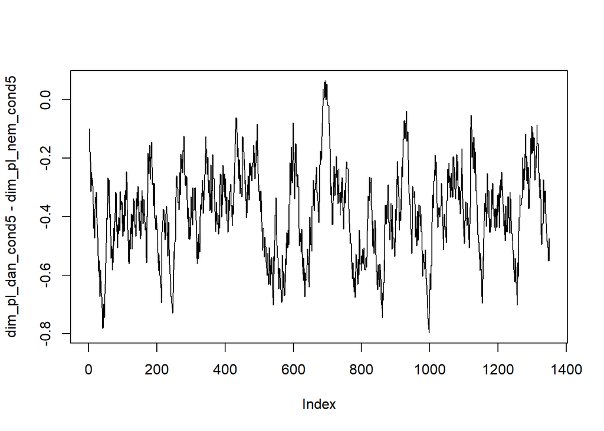

```r
plot(dim_pl_dan_cond5 - dim_pl_nem_cond5, type = 'l')
```

## Condition 6: (nem type and token) 12 token 12 type (dan 3 token 3 type)

```r
cond6 = read_csv('../Experiment/Condition6.csv')
cond6 = cond6 %>%
  mutate(stem = orthoCoding(stem)) %>%
  mutate(type = ifelse((suffix == 'dan' | suffix == 'sil'), 'big_pl', 'dim_sg'))

cond6 = cond6 %>%
  mutate(key = paste0(stem, '_', type))

cond6_key = cond6 %>%
  group_by(key, suffix) %>%
  summarize(frequency = table(key))
```

[output not shown]

```r
colnames(cond6_key) = c('Cues', 'Outcomes', 'Frequency')

data_cond6 = cond6_key %>%
  mutate(Frequency = as.numeric(Frequency) * 5)
```

### Rescorla Predictions

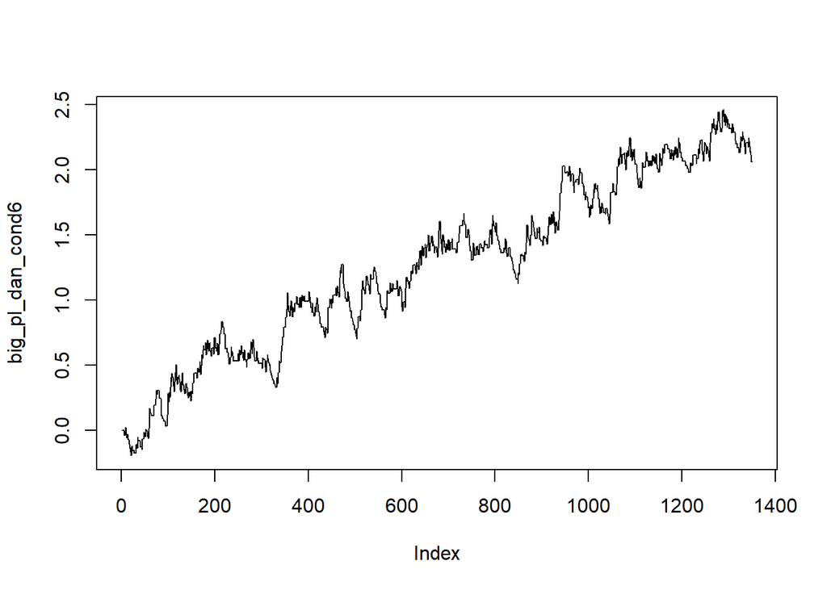

```r
n = 10
b = sqrt(.1)

cond_6_df = as.data.frame(rep(c('big', 'pl', 'dim'), times = 2)) %>%
  mutate(traceOutcome = rep(c('dan', 'nem'), each = 3))

colnames(cond_6_df) = c('traceCue', 'traceOutcome')

rw_preds_cond6 = pmap_dfr(cond_6_df, ~data.frame(weightvector = RescorlaLogistic(data_cond6, nruns = n, traceCue = ..1, traceOutcome = ..2, beta2 = b, alpha = b, beta1 = b, ap = T)[[1]], 'cue' = ..1, 'outcome' = ..2)) %>%
  group_by(cue, outcome) %>%
  group_split()

big_dan_cond6 = rw_preds_cond6[[1]] #ap = T means you're learning something if the cue is absent
pl_dan_cond6 = rw_preds_cond6[[5]]

dim_dan_cond6 = rw_preds_cond6[[3]]
#pl_dan_cond1 = RescorlaLogistic(data_cond1, nruns = n, traceCue='pl', traceOutcome = 'dan', beta2=b, alpha=b, beta1=b, ap = F)

big_nem_cond6 = rw_preds_cond6[[2]]
pl_nem_cond6 = rw_preds_cond6[[6]]

dim_nem_cond6 = rw_preds_cond6[[4]]
#pl_nem_cond1 = RescorlaLogistic(data_cond1, nruns = n, traceCue='pl', traceOutcome = 'nem', beta2=b, alpha=b, beta1=b, ap = F)

big_pl_dan_cond6 = big_dan_cond6$weightvector + pl_dan_cond6$weightvector
dim_pl_dan_cond6 = dim_dan_cond6$weightvector + pl_dan_cond6$weightvector
big_pl_nem_cond6 = big_nem_cond6$weightvector + pl_nem_cond6$weightvector
dim_pl_nem_cond6 = dim_nem_cond6$weightvector + pl_nem_cond6$weightvector


plot(big_pl_dan_cond6, type='l' )
```

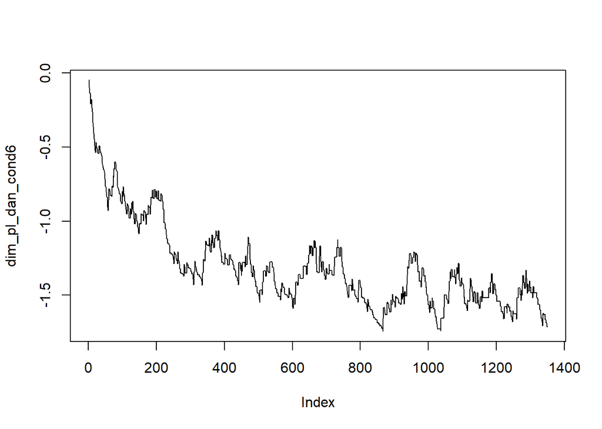

```r
plot(dim_pl_dan_cond6, type = 'l')
```